# Второе задание. Вариант 10. Заяц Артур.

Будем брать нашу особую точку и брать по 10 случайных точек из её окрестности. В каждой точке будем строить решение на интервале времени от 0 до 100.

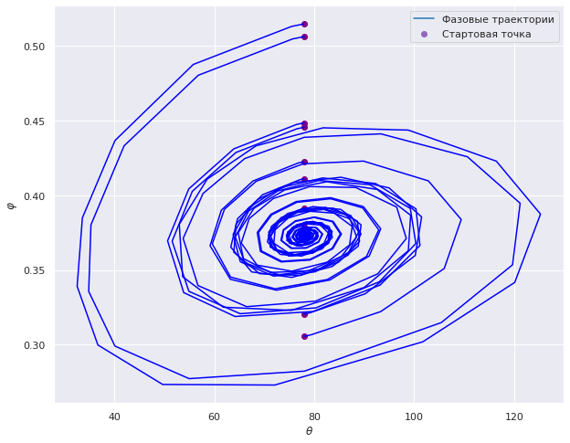

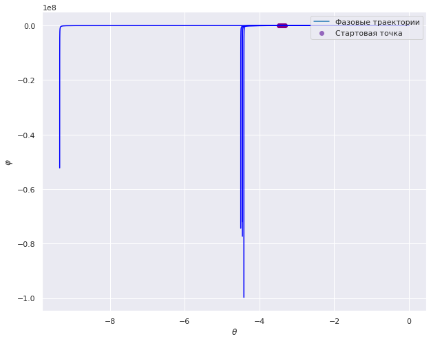

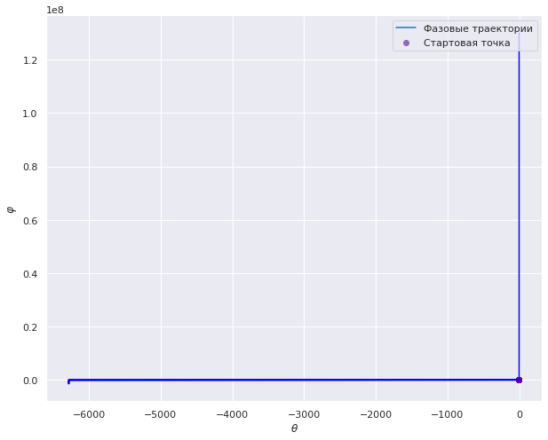

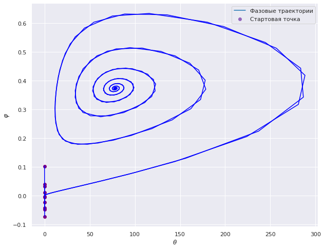

```python
def bias(y): #Для исследований решений вблизи! особых точек
    return np.array([y[0] + np.random.normal(scale=0.2), y[1] + np.random.normal(scale=0.2)])

for i in range(4):
    plt.figure(figsize = (10,8))

    for _ in range(10):

        rk_res = sps.integrate.solve_ivp(kinetic,(0,100), bias(dotes[i]), rtol = 1e-5) #Считаем

        plt.plot(rk_res['y'][0],rk_res['y'][1], color = 'blue') #Рисуем траекторию

        plt.scatter(rk_res['y'][0][0],rk_res['y'][1][0], color = 'purple')

    plt.plot([],[],c ='tab:blue', label='Фазовые траектории')
    plt.scatter([],[],c='tab:purple', label='Стартовая точка')

    plt.xlabel(r'$\theta$')
    plt.ylabel(r'$\varphi$')

    plt.legend(loc = 'upper right')
```

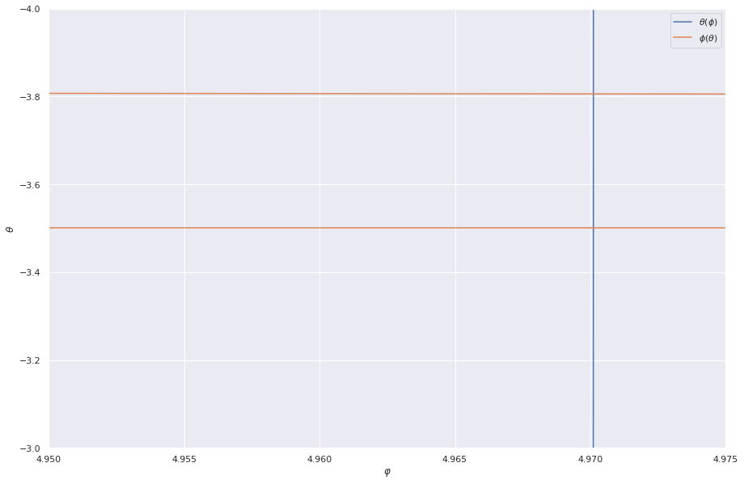

```python
phi, theta = np.linspace(-30,30,1000), np.linspace(-100,100,10000)

plt.figure(figsize = (15,10))

plt.plot(phi, k_2 * phi / (beta * (1 - phi / C) * (1 + (phi/phi_0)**2)), label = r'$\theta(\phi)$')
plt.plot(1 / gamma * (alpha * theta/(theta + theta_0) - k_1), theta, label = r'$\phi(\theta)$')
plt.xlim(4.950,4.975)
plt.ylim(-3,-4)
plt.xlabel(r'$\varphi$')
plt.ylabel(r'$\theta$')
plt.legend();
```

Оказывается, там целых 2 точки. Посмотрим на фазовые траектории.

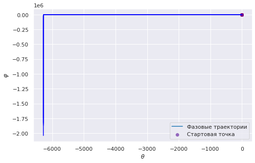

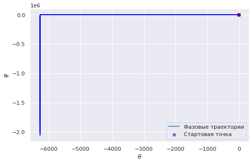

```python
for y in [[-3.5,4.970],[-3.8,4.970]]:
    plt.figure(figsize = (8,5))
    for _ in range(10):

        rk_res = sps.integrate.solve_ivp(kinetic,(0,100), bias(y), rtol = 1e-5) #Считаем

        plt.plot(rk_res['y'][0],rk_res['y'][1], color = 'blue') #Рисуем траекторию

        plt.scatter(rk_res['y'][0][0],rk_res['y'][1][0], color = 'purple')

    plt.plot([],[],c ='tab:blue', label='Фазовые траектории')
    plt.scatter([],[],c='tab:purple', label='Стартовая точка')

    plt.xlabel(r'$\theta$')
    plt.ylabel(r'$\varphi$')

    plt.legend(loc = 'lower right');
```

Опять ничего не нашли. Попробуй сделать это теоритически. Найдём особые точки для линеаризованной системы и исследуем характер поведения фазовых траекторий(файл с линеаризацией приложен к письму с решением). Линеаризовав систему, получем те же самые особые точки, что и нашли ранее.